# Module 1, Lesson 2: Installing R and RStudio

This document walks through two options for using R and RStudio. The first option is the same as that discussed in the guided practice: download and install R and RStudio on your own computer. To use R, you find the RStudio icon on your computer and open it. The second option was not discussed in the guided practice; it is a cloud-based option that does not require you to download any software but does requires a browser with an active internet connection.

## Option 1

First go to https://cran.r-project.org/ and look for the links that are labeled ‘Download R for …’ (see below for a screenshot of what you should be looking for as of the time of this writing). Click the link corresponding to your operating system and follow the instructions to download and install R. Unfortunately, R is not currently available for mobile devices.

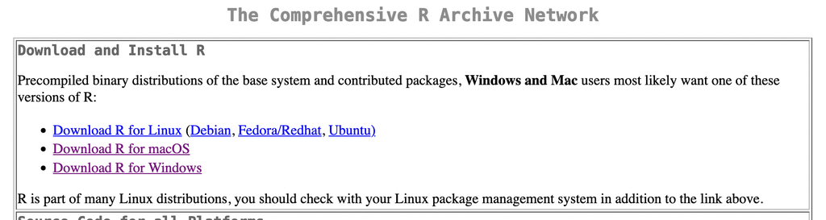

**Image description: screen capture from https://cran.r-project.org/ as of 11-Oct-2022**

Second, having downloaded R, go to https://posit.co/downloads/ to get RStudio (Posit is the name of the company that developed RStudio. In November 2022, the name of the company, which was *also* RStudio, changed to Posit) Look for a link to the RStudio Desktop Open Source Edition (AGPL v3) (see below for a screenshot of what you should be looking for as of the time of this writing)

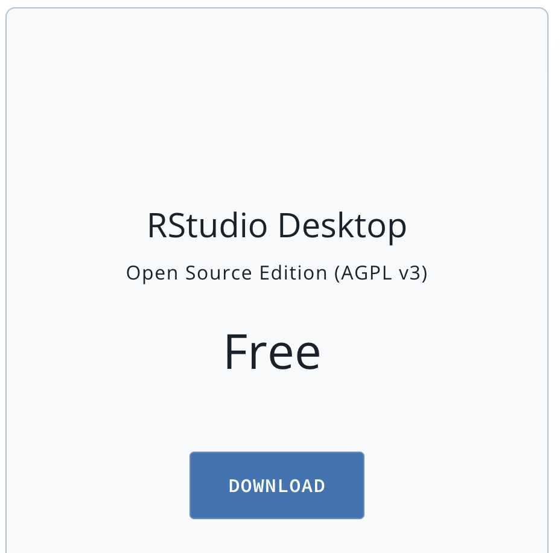

**Image description: screen capture from https://posit.co/downloads/ as of 1-Dec-2022**

Clicking through this link, you will see a webpage with 2 steps. You’ve already done Step 1 (installing R), so scroll down to Step 2 (‘Install RStudio Desktop’). Click the link corresponding to your operating system and follow the instructions to install it on your computer.

## Option 2

Go to https://posit.cloud/ (see below for a screenshot of what you should be looking for as of the time of this writing) and click ‘GET STARTED’. Follow the instructions to create a free account and then login.

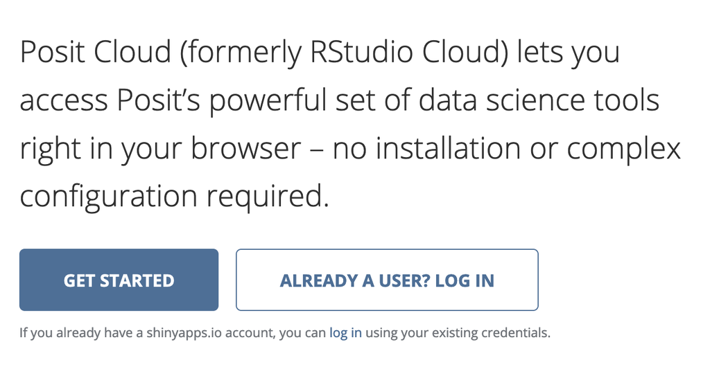

**Image description: screen capture from https://posit.cloud/ as of 1-Dec-2022**

Once you’ve logged in, create a new project by clicking ‘New Project’ in the upper right of the screen, then ‘New RStudio Project’.

[figure not shown]

**Image description: creating a new R project on posit.cloud**

Your new project is not-yet named, as can be seen in the upper left of your screen:

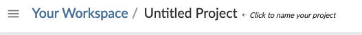

**Image description: an untitled R project on posit.cloud**

Name your new project ‘GlobalFindex’:

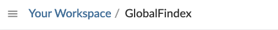

**Image description: R project on posit.cloud after naming it ‘GlobalFindex’**

At this point, it is basically as if you have RStudio open on your own personal computer, the main differences being that everything may be slightly less ‘speedy’ due to the fact that you are running an R session on a different computer. After a period of inactivity, you may be automatically logged off. In this case, you can re-login to your cloud session and pick up where you left off.